# Tree models, neural networks, and SGD

## Example: logistic regression

- Logit link, $p$ the probability of the positive class; the loss is the cross-entropy
  $$l(\theta) = - \sum_{i=1}^n \left[ y_i \log p_i + (1-y_i) \log (1-p_i) \right]$$
- With $p_i = 1/\left(1 + \exp(-\theta_0 - \theta_1 x_{i1} - \ldots - \theta_p x_{ip})\right)$ the gradient is
  $$\nabla l(\theta) = - X^\top (y - p)$$

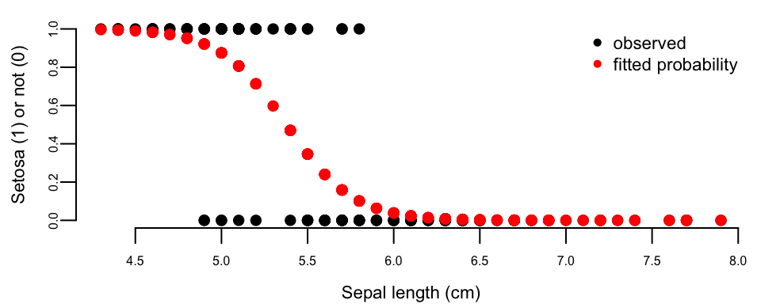

Logistic regression fitted by gradient descent on iris.

## Stochastic gradient descent

- Replace the full-data gradient with the gradient over a random batch $B \subseteq \{1,2,\ldots,n\}$, with batch size $|B|$
  $$\nabla l(\theta) \approx \dfrac{1}{|B|} \sum_{i \in B} \nabla l(y_i, f(x_i, \theta))$$
- Gradient descent with noisy gradients (mini-batch gradients). Works when data do not fit in memory
- Rooted in stochastic approximation (Robbins and Monro, 1951): the expected gradient is replaced by its Monte Carlo approximation
- Mini-batch regime: $|B| \ll n$, typically $|B| \in \{32,64,\ldots,1024\}$

## SGD: batch size

- Shuffle the data first: sorted data make batches correlated and slow convergence
- Larger batches need more memory, parallelize better and give less noisy gradients
- For non-convex objectives, noisier gradients (small batches) often give higher-quality solutions

Intercept $\theta_0$ for batch sizes 5, 15, 30 (dashed line: 27.83), by iteration and by computation (thousands of iterations with batch size 5):

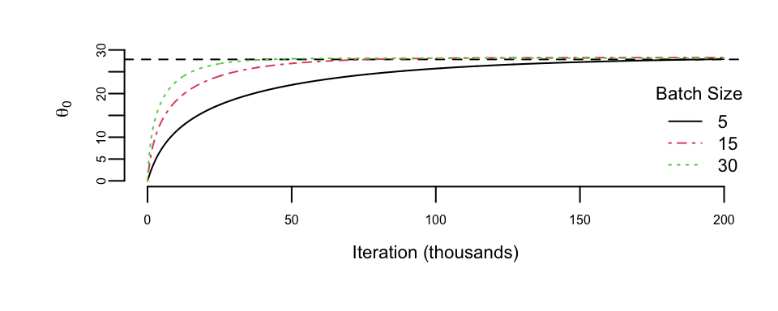

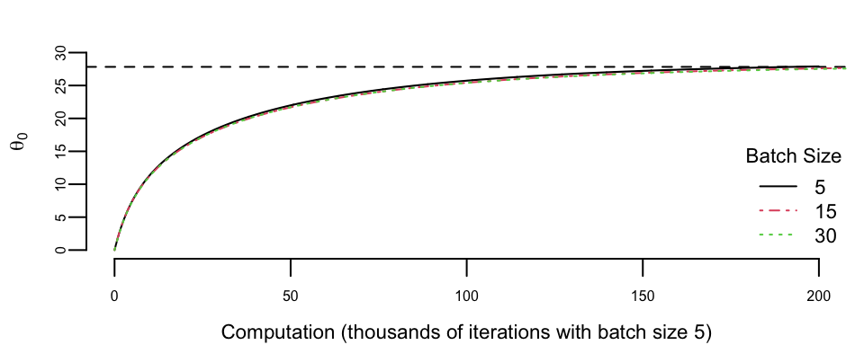

## Automatic differentiation: four ways to differentiate

- By hand: slow and error-prone
- Numerical: $f'(x) \approx (f(x+h)-f(x))/h$. Large $h$ gives truncation error, small $h$ gives rounding error
- Symbolic: analytical expression of the derivative
- Automatic differentiation (AD): recursively applies the chain rule and gives the exact derivative value at a specific point, from code (including if statements and loops)
- Example: the logistic function
  $$f(x) = \frac{1}{1+e^{-(Wx+b)}}$$

```
sigmoid = function(x,b,w){
  v1 = w*x
  v2 = v1 + b
  v3 = 1/(1+exp(-v2))
}
```

## Chain rule for the sigmoid

- With $\sigma(z) = 1/(1+e^{-z})$, $\sigma'(z) = \sigma(z)(1-\sigma(z))$
  $$\frac{\partial f}{\partial w} = \frac{\partial v_3}{\partial v_2} \cdot \frac{\partial v_2}{\partial v_1} \cdot \frac{\partial v_1}{\partial w} = v_3(1-v_3) \cdot 1 \cdot x$$
  $$\frac{\partial f}{\partial b} = \frac{\partial v_3}{\partial v_2} \cdot \frac{\partial v_2}{\partial b} = v_3(1-v_3) \cdot 1$$
- Here $v_1 = wx$, $v_2 = v_1 + b$, $v_3 = f$

## Forward mode

- An auxiliary dual variable tracks the derivative on each line. Take `x=2, w=3, b=-5`

| Function calculations | Derivative calculations |
| --- | --- |
| 1. `v1 = w*x = 6` | 1. `dv1 = w = 3` (derivative of `v1` with respect to `x`) |
| 2. `v2 = v1 + b = 1` | 2. `dv2 = dv1 = 3` (derivative of `v2` with respect to `x`) |
| 3. `v3 = 1/(1+exp(-v2)) = 0.731` | 3. `dv3 = dv2*v3*(1-v3) = 0.590` |

- `dv1, dv2, dv3` are the derivatives of `v1, v2, v3` with respect to $x$, called dual variables
- Implemented by source code modification or operator overloading

## Reverse mode

- Applies the chain rule recursively, starting from the outer function

| Function calculations | Derivative calculations |
| --- | --- |
| 1. `v1 = w*x = 6` | 4. `dv1 = dv2*dv2dv1 = 0.197; df/dx = dv1*w = 0.590` |
| 2. `v2 = v1 + b = 1` | 3. `dv2dv1 = 1; dv2 = dv3*dv3dv2 = 0.197` |
| 3. `v3 = 1/(1+exp(-v2)) = 0.731` | 2. `dv3 = dv4 = 1; dv3dv2 = v3*(1-v3) = 0.197` |
| 4. `v4 = v3` | 1. `dv4 = 1` |

## Forward versus reverse mode

- Forward mode: propagates derivatives with the computation, from inputs to outputs. Efficient when the number of inputs is less than the number of outputs
- Reverse mode: propagates derivatives against the computation, from outputs to inputs. Efficient when the number of outputs is less than the number of inputs
- A neural network has millions of parameters (inputs to the loss) and one scalar loss (one output), so reverse mode is dramatically more efficient
- In neural networks, reverse AD is called backpropagation

## Computational graph

- Single sigmoid unit, composition of affine and sigmoid functions
- Numbers in the nodes are values at a specific point. Solid arrows: forward pass, from inputs (x, w, b) to the output v3. Dashed arrows: backward pass, gradient values flow from the output back to the inputs

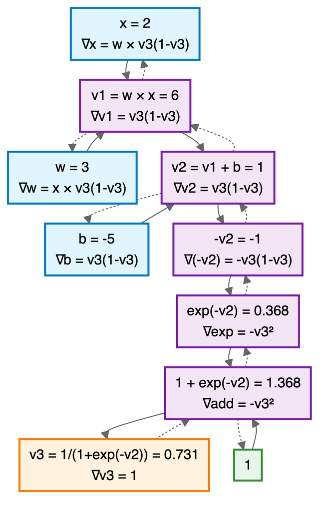

Computational Graph for Sigmoid Function

## Backpropagation in practice

- For deep learning, derivatives come from reverse AD applied to a model defined as a composition of functions
- PyTorch defines the model in a general-purpose language, TensorFlow through a sequence of function calls
- PyTorch relies on the `autograd` library, which finds gradients by backpropagation
- Delta rule for a single-layer perceptron with $\hat{y} = \sigma(w^\top x + b)$, squared-error loss $(\hat{y}-y)^2/2$ and learning rate $\alpha$
  $$w^{t+1} = w^t - \alpha (\hat{y} - y) \sigma'(w^\top x + b) x$$
- For a hidden layer $h = \sigma_1(W_1 x + b_1)$, $\hat{y} = \sigma_2(W_2 h + b_2)$ and loss $L$, the chain rule gives
  $$\frac{\partial L}{\partial W_1} = \frac{\partial L}{\partial \hat{y}} \cdot \frac{\partial \hat{y}}{\partial h} \cdot \frac{\partial h}{\partial W_1}$$

## Momentum

- Vanilla SGD does not guarantee descent at every iteration; progress can be slow when gradients are noisy
- Momentum adds memory by combining new gradient information with previous search directions. $v$ is the velocity, $t_k$ the step size, $g$ the gradient, $(W,b)$ the parameters
  $$v^{k+1} = \mu v^k - t_k g((W,b)^k), ~~ (W,b)^{k+1} = (W,b)^k + v^{k+1}$$
- $\mu$ controls the damping of the update
- Nesterov momentum: gradient at the point predicted by the momentum (look-ahead)
  $$v^{k+1} = \mu v^k - t_k g((W,b)^k + \mu v^k), ~~ (W,b)^{k+1} = (W,b)^k + v^{k+1}$$

## Adaptive learning rates

- AdaGrad scales the learning rate per parameter by the history of gradients, $c$ the accumulated squared gradient and $\epsilon$ a small constant (e.g., $10^{-8}$)
  $$c^{k+1} = c^k + g(\theta^k)^2, ~~ \theta^{k+1} = \theta^k - \frac{t_k}{\sqrt{c^{k+1}} + \epsilon} g(\theta^k)$$
- RMSprop uses an exponentially weighted moving average, with decay $\rho$
  $$c^{k+1} = \rho c^k + (1-\rho) g(\theta^k)^2$$
- Adam combines RMSprop with momentum, with first moment $m$ and second moment $c$
  $$m^{k+1} = \beta_1 m^k + (1-\beta_1) g(\theta^k), ~~ c^{k+1} = \beta_2 c^k + (1-\beta_2) g(\theta^k)^2$$
  $$\theta^{k+1} = \theta^k - \frac{t_k}{\sqrt{\hat{c}^{k+1}} + \epsilon} \hat{m}^{k+1}$$
- Bias-corrected: $\hat{m}^{k+1} = m^{k+1}/(1-\beta_1^{k+1})$, $\hat{c}^{k+1} = c^{k+1}/(1-\beta_2^{k+1})$, $m^0 = c^0 = 0$. Typical $\beta_1 = 0.9$, $\beta_2 = 0.999$, $\epsilon = 10^{-8}$

## Summary of optimizers

| Method | Key Idea | Update Rule |
| --- | --- | --- |
| SGD | Noisy gradient estimates | $\theta^{k+1} = \theta^k - t_k g^k$ |
| Momentum | Accumulate gradient direction | $v^{k+1} = \mu v^k - t_k g^k$; $\theta^{k+1} = \theta^k + v^{k+1}$ |
| Nesterov | Look-ahead gradient | $v^{k+1} = \mu v^k - t_k g(\theta^k + \mu v^k)$; $\theta^{k+1} = \theta^k + v^{k+1}$ |
| AdaGrad | Per-parameter learning rates | Scale by $1/\sqrt{\sum g^2}$ |
| RMSprop | Exponential moving average | Scale by $1/\sqrt{\text{EMA}(g^2)}$ |
| Adam | Momentum + adaptive rates | Combines first and second moment estimates |

- Second-order (Newton): $\theta^{+} = \theta - \{ \nabla^2 f(\theta) \}^{-1} \nabla f(\theta)$. SGD approximates the inverse Hessian by $t_k I$, with $I$ the identity. Rarely used in deep learning because the Hessian is too large to compute and store